# L11 Functions and Iteration

Data Science 1 with R (STAT 301-1)

Author

Olivia Allen

Published

November 26, 2024

**Github Repo Link ✅**

https://github.com/stat301-1-2024-fall/L11-functions-and-iteration-oliviaallen2003.git

## Packages & Datasets

Datasets referenced in this lab are from the `palmerpenguins` and `mpg` packages.

```r
# Loading package(s)
library(tidyverse)
library(palmerpenguins)
library(fs)
```

## Exercises

### Exercise 1 ✅

Practice turning the following code snippets into functions. Think about what each function does. What would you call it? How many arguments does it need?

```r
# function 1
mean(is.na(x))

# function 2
x / sum(x, na.rm = TRUE)

# function 3
round(x / sum(x, na.rm = TRUE) * 100, 1)
```

**Solution**

```r
# function 1
proportion_na <- function(x) {
  mean(is.na(x))
}

# function 2
proportions <- function(x) {
  x / sum(x, na.rm = TRUE)
}

# function 3
percentages <- function(x) {
  round(x / sum(x, na.rm = TRUE) * 100, 1)
}
```

### Exercise 2✅

Write a function that returns how old you are in years, given your birthday (as `"YYYY-MM-DD"`).

**Solution**

```r
calculate_age <- function(birthday) {
  birth_date <- as.Date(birthday, format = "%Y-%m-%d")
  current_date <- Sys.Date()
  age <- as.numeric(difftime(current_date, birth_date, units = "weeks")) %/% 52.25

  return(age)
}

calculate_age("2003-05-08")
```

```
[1] 21
```

### Exercise 3✅

Write a function that computes the mean, standard deviation, and count given a dataset and a numeric variable.

Test your function using the `penguins` dataset and a numeric variable of your choice.

**Solution**

```r
sum_stats <- function(.data, x) {
  .data |>
    summarize(
      mean = mean({{ x }}, na.rm = TRUE),
      sd = sd({{ x }}, na.rm = TRUE),
      n = n(),
      .groups = "drop"
    )
}

sum_stats(penguins, bill_length_mm)
```

```
# A tibble: 1 × 3
   mean    sd     n
  <dbl> <dbl> <int>
1  43.9  5.46   344
```

### Exercise 4✅

Write a function that counts the number of missing observations given a dataset and a variable.

Test your function using the `penguins` dataset and a variable of your choice.

**Solution**

```r
count_missing <- function(data, variable) {
  sum(is.na(data[[variable]]))
}

count_missing(penguins, "sex")
```

```
[1] 11
```

### Exercise 5✅

Write a function that draws a scatterplot given a dataset and x and y variables. Add a line of best fit and an appropriate title to the plot.

Test your function using the `penguins` dataset and an x and y variable of your choice.

**Solution**

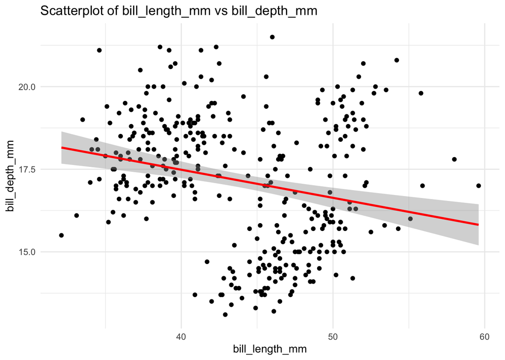

```r
scatter_with_lm <- function(data, x, y) {
  ggplot(data, aes(x = .data[[x]], y = .data[[y]])) +
    geom_point() +
    geom_smooth(method = "lm", color = "red") +
    labs(
      title = paste("Scatterplot of", x, "vs", y),
      x = x,
      y = y
    ) +
    theme_minimal()
}

scatter_with_lm(penguins, "bill_length_mm", "bill_depth_mm")
```

### Exercise 6✅

Use the `across()` function to…

1. compute the number of unique values in each column of `penguins`
2. compute the `mean` of every numeric column of `penguins`.

**Solution**

```r
# a)
penguins |>
  summarise(across(everything(), ~ n_distinct(.)))
```

```
# A tibble: 1 × 8
  species island bill_length_mm bill_depth_mm flipper_length_mm body_mass_g
    <int>  <int>          <int>         <int>             <int>       <int>
1       3      3            165            81                56          95
# ℹ 2 more variables: sex <int>, year <int>
```

```r
# b)
penguins |>
  summarise(across(where(is.numeric), ~ mean(., na.rm = TRUE)))
```

```
# A tibble: 1 × 5
  bill_length_mm bill_depth_mm flipper_length_mm body_mass_g  year
           <dbl>         <dbl>             <dbl>       <dbl> <dbl>
1           43.9          17.2              201.       4202. 2008.
```

### Exercise 7✅

Write code that uses one of the map functions to:

1. compute the number of unique values in each column of `penguins`
2. compute the `mean` of every numeric column in `penguins`.

**Solution**

```r
# a)
map_dbl(penguins, ~ n_distinct(.))
```

```
          species            island    bill_length_mm     bill_depth_mm
                3                 3               165                81
flipper_length_mm       body_mass_g               sex              year
               56                95                 3                 3
```

```r
# b)
map_dbl(penguins |>
          select(where(is.numeric)), ~ mean(., na.rm = TRUE))
```

```
   bill_length_mm     bill_depth_mm flipper_length_mm       body_mass_g
         43.92193          17.15117         200.91520        4201.75439
             year
       2008.02907
```

### Exercise 8✅

Write a `for` loop that uses your function in Exercise 3 to compute the mean, standard deviation, and count of every numeric variable in the `penguins` dataset.

Output the results as a nicely formatted html table.

**Solution**

```r
numeric_vars <- penguins |>
  select(where(is.numeric)) |>
  colnames()

for(var in numeric_vars){
  sum_stats(penguins, x = !!sym(var))
  print(var)
}
```

```
[1] "bill_length_mm"
[1] "bill_depth_mm"
[1] "flipper_length_mm"
[1] "body_mass_g"
[1] "year"
```

```r
sum_stats(penguins, bill_length_mm)
```

```
# A tibble: 1 × 3
   mean    sd     n
  <dbl> <dbl> <int>
1  43.9  5.46   344
```

### Exercise 9✅

Write a `for` loop that plots the distribution of each variable in the `penguins` dataset and saves each plot to a `\plots` subdirectory.

Hint: need to determine if a variable is numeric or categorical to determine the appropriate plot.

**Solution**

```r
dir_create("plots")

for (variable in names(penguins)) {
  plot_path <- file.path("plots", paste0(variable, "_distribution.png"))

  if (is.numeric(penguins[[variable]])) {
    plot <- ggplot(penguins, aes(x = .data[[variable]])) +
      geom_histogram(
        bins = 30,
        fill = "blue",
        alpha = 0.7,
        color = "black"
      ) +
      labs(
        title = paste("Distribution of", variable),
        x = variable,
        y = "Count"
      ) +
      theme_minimal()
  } else {
    plot <- ggplot(penguins, aes(x = factor(.data[[variable]]))) +
      geom_bar(
        fill = "orange",
        alpha = 0.7,
        color = "black"
      ) +
      labs(
        title = paste("Distribution of", variable),
        x = variable,
        y = "Count"
      ) +
      theme_minimal() +
      theme(axis.text.x = element_text(angle = 45, hjust = 1))
  }
  ggsave(plot_path, plot, width = 7, height = 5)
}
```

### Exercise 10✅

Determine which variables in the `mpg` dataset should be factors and convert them to factors using a `for` loop.

**Solution**

```r
mpg |>
  map(n_distinct)
```

```
$manufacturer
[1] 15

$model
[1] 38

$displ
[1] 35

$year
[1] 2

$cyl
[1] 4

$trans
[1] 10

$drv
[1] 3

$cty
[1] 21

$hwy
[1] 27

$fl
[1] 5

$class
[1] 7
```

```r
mpg |>
  map(typeof)
```

```
$manufacturer
[1] "character"

$model
[1] "character"

$displ
[1] "double"

$year
[1] "integer"

$cyl
[1] "integer"

$trans
[1] "character"

$drv
[1] "character"

$cty
[1] "integer"

$hwy
[1] "integer"

$fl
[1] "character"

$class
[1] "character"
```

```r
factors_vars <- c("manufacturer", "year", "cyl", "drv", "fl", "class")

for (var in factors_vars){
  mpg[[var]] <- factor(mpg[[var]])
}

str(mpg)
```

```
tibble [234 × 11] (S3: tbl_df/tbl/data.frame)
 $ manufacturer: Factor w/ 15 levels "audi","chevrolet",..: 1 1 1 1 1 1 1 1 1 1 ...
 $ model       : chr [1:234] "a4" "a4" "a4" "a4" ...
 $ displ       : num [1:234] 1.8 1.8 2 2 2.8 2.8 3.1 1.8 1.8 2 ...
 $ year        : Factor w/ 2 levels "1999","2008": 1 1 2 2 1 1 2 1 1 2 ...
 $ cyl         : Factor w/ 4 levels "4","5","6","8": 1 1 1 1 3 3 3 1 1 1 ...
 $ trans       : chr [1:234] "auto(l5)" "manual(m5)" "manual(m6)" "auto(av)" ...
 $ drv         : Factor w/ 3 levels "4","f","r": 2 2 2 2 2 2 2 1 1 1 ...
 $ cty         : int [1:234] 18 21 20 21 16 18 18 18 16 20 ...
 $ hwy         : int [1:234] 29 29 31 30 26 26 27 26 25 28 ...
 $ fl          : Factor w/ 5 levels "c","d","e","p",..: 4 4 4 4 4 4 4 4 4 4 ...
 $ class       : Factor w/ 7 levels "2seater","compact",..: 2 2 2 2 2 2 2 2 2 2 ...
```

### Exercise 11✅

The `data` subdirectory has various CSV files that you want to read in.

First, store their paths in a vector: `files <- dir("data/", pattern = "\\.csv$", full.names = TRUE)`.

1. Write a for loop that will read in each file individually.
2. Write a for loop that will load the files into a single data frame.

**Solution**

```r
files <- dir("data/", pattern = "\\.csv$", full.names = TRUE)
```

```r
data_list <- list()

for (file in files) {
  data_list[[file]] <- read.csv(file)
}

str(data_list)
```

```
List of 3
 $ data//housing_ca.csv:'data.frame':   9 obs. of  8 variables:
  ..$ longitude   : num [1:9] -122 -122 -122 -122 -122 ...
  ..$ latitude    : num [1:9] 37.9 37.9 37.9 37.9 37.9 ...
  ..$ house_age   : int [1:9] 41 10 30 40 52 35 60 52 42
  ..$ sqr_footage : int [1:9] 880 7099 1467 1274 1627 919 2535 3104 2555
  ..$ num_bed     : int [1:9] 1 7 3 3 3 2 4 5 5
  ..$ num_bath    : int [1:9] 1 4 2 1 2 1 3 4 3
  ..$ price_listed: int [1:9] 229000 1200000 452100 341300 342200 269700 299200 441400 426700
  ..$ price_sold  : int [1:9] 240000 999000 464900 340000 340000 260000 320000 440000 420000
 $ data//housing_il.csv:'data.frame':   7 obs. of  8 variables:
  ..$ longitude   : num [1:7] -87.8 -87.8 -87.7 -87.8 -87.8 ...
  ..$ latitude    : num [1:7] 42.1 42.1 42.1 42.1 42.1 ...
  ..$ house_age   : int [1:7] 45 35 55 32 60 70 25
  ..$ sqr_footage : int [1:7] 3500 3000 2500 1400 1600 2100 3800
  ..$ num_bed     : int [1:7] 5 4 3 2 2 3 5
  ..$ num_bath    : int [1:7] 3 3 2 1 2 1 4
  ..$ price_listed: int [1:7] 550000 500000 350000 280000 320000 340000 650000
  ..$ price_sold  : int [1:7] 560000 489000 375000 270000 330000 320000 650000
 $ data//housing_ma.csv:'data.frame':   7 obs. of  8 variables:
  ..$ longitude   : num [1:7] -71.1 -71 -71.1 -71.1 -71 ...
  ..$ latitude    : num [1:7] 42.4 42.4 42.4 42.3 42.4 ...
  ..$ house_age   : int [1:7] 65 60 35 49 52 55 60
  ..$ sqr_footage : int [1:7] 750 2500 1467 900 1100 2900 2300
  ..$ num_bed     : int [1:7] 1 4 3 1 2 4 3
  ..$ num_bath    : int [1:7] 1 2 2 1 2 3 2
  ..$ price_listed: int [1:7] 229000 440000 320000 280000 330000 480000 420000
  ..$ price_sold  : int [1:7] 240000 460000 320000 270000 310000 499000 415000
```

```r
combined_data <- data.frame()

for (file in files) {
  temp_data <- read.csv(file)
  combined_data <- rbind(combined_data, temp_data)
}

str(combined_data)
```

```
'data.frame':   23 obs. of  8 variables:
 $ longitude   : num  -122 -122 -122 -122 -122 ...
 $ latitude    : num  37.9 37.9 37.9 37.9 37.9 ...
 $ house_age   : int  41 10 30 40 52 35 60 52 42 45 ...
 $ sqr_footage : int  880 7099 1467 1274 1627 919 2535 3104 2555 3500 ...
 $ num_bed     : int  1 7 3 3 3 2 4 5 5 5 ...
 $ num_bath    : int  1 4 2 1 2 1 3 4 3 3 ...
 $ price_listed: int  229000 1200000 452100 341300 342200 269700 299200 441400 426700 550000 ...
 $ price_sold  : int  240000 999000 464900 340000 340000 260000 320000 440000 420000 560000 ...
```